# ECE592 Final Project

#### Pattern identification among records with missing values

```python
# extract date and time information from 'Date_Time' column
householdPower['year'] = householdPower.Date.dt.year
householdPower['weekday'] = householdPower.Date.dt.weekday
householdPower['month'] = householdPower.Date.dt.month
householdPower['hour'] = householdPower.Date_Time.dt.hour
householdPower['day'] = householdPower.Date_Time.dt.day
householdPower = householdPower.reset_index()
```

```python
# Identify and group dates having missing value
dt = {}
for eachdate in hhpMissingData.Date.unique():
    dt[eachdate] = hhpMissingData[hhpMissingData.Date == eachdate].shape[0]

dt = pd.DataFrame({'Date': dt.keys(), 'noOfDaysMissingData': dt.values()})
```

```python
for e in dt.noOfDaysMissingData.unique():
    if e not in (1440,2,1):
        display(dt[dt.noOfDaysMissingData == e]) # displaying dates having missing values and corresponding number of minutes on the given date
```

|  | Date | noOfDaysMissingData |
| --- | --- | --- |
| 6 | 2007-04-28 | 1419 |

|  | Date | noOfDaysMissingData |
| --- | --- | --- |
| 8 | 2007-04-30 | 864 |

|  | Date | noOfDaysMissingData |
| --- | --- | --- |
| 11 | 2007-06-09 | 38 |
| 39 | 2009-02-01 | 38 |

|  | Date | noOfDaysMissingData |
| --- | --- | --- |
| 14 | 2007-07-15 | 130 |

|  | Date | noOfDaysMissingData |
| --- | --- | --- |
| 16 | 2007-08-01 | 21 |

|  | Date | noOfDaysMissingData |
| --- | --- | --- |
| 32 | 2008-10-25 | 43 |

|  | Date | noOfDaysMissingData |
| --- | --- | --- |
| 33 | 2008-11-10 | 6 |

|  | Date | noOfDaysMissingData |
| --- | --- | --- |
| 36 | 2008-12-10 | 70 |

|  | Date | noOfDaysMissingData |
| --- | --- | --- |
| 41 | 2009-02-17 | 24 |

|  | Date | noOfDaysMissingData |
| --- | --- | --- |
| 46 | 2009-05-26 | 3 |

|  | Date | noOfDaysMissingData |
| --- | --- | --- |
| 47 | 2009-06-13 | 1410 |

|  | Date | noOfDaysMissingData |
| --- | --- | --- |
| 49 | 2009-06-15 | 455 |

|  | Date | noOfDaysMissingData |
| --- | --- | --- |
| 50 | 2009-07-10 | 4 |

|  | Date | noOfDaysMissingData |
| --- | --- | --- |
| 51 | 2009-08-13 | 891 |

|  | Date | noOfDaysMissingData |
| --- | --- | --- |
| 58 | 2010-01-12 | 547 |

|  | Date | noOfDaysMissingData |
| --- | --- | --- |
| 60 | 2010-01-14 | 1142 |

|  | Date | noOfDaysMissingData |
| --- | --- | --- |
| 64 | 2010-03-20 | 1208 |

|  | Date | noOfDaysMissingData |
| --- | --- | --- |
| 65 | 2010-03-21 | 819 |

|  | Date | noOfDaysMissingData |
| --- | --- | --- |
| 71 | 2010-08-17 | 178 |

|  | Date | noOfDaysMissingData |
| --- | --- | --- |
| 76 | 2010-08-22 | 1288 |

|  | Date | noOfDaysMissingData |
| --- | --- | --- |
| 77 | 2010-09-25 | 1204 |

|  | Date | noOfDaysMissingData |
| --- | --- | --- |
| 80 | 2010-09-28 | 1153 |

```python
 display(dt[dt.noOfDaysMissingData == 1440]) # dates where missing values for a day time
```

|  | Date | noOfDaysMissingData |
| --- | --- | --- |
| 7 | 2007-04-29 | 1440 |
| 48 | 2009-06-14 | 1440 |
| 59 | 2010-01-13 | 1440 |
| 72 | 2010-08-18 | 1440 |
| 73 | 2010-08-19 | 1440 |
| 74 | 2010-08-20 | 1440 |
| 75 | 2010-08-21 | 1440 |
| 78 | 2010-09-26 | 1440 |
| 79 | 2010-09-27 | 1440 |

```python
 display(dt[dt.noOfDaysMissingData == 2]) # dates where missing values for 2 minutes
```

|  | Date | noOfDaysMissingData |
| --- | --- | --- |
| 0 | 2006-12-21 | 2 |
| 1 | 2006-12-30 | 2 |
| 4 | 2007-02-22 | 2 |
| 12 | 2007-06-19 | 2 |
| 18 | 2007-09-26 | 2 |
| 19 | 2007-10-23 | 2 |
| 25 | 2008-02-23 | 2 |
| 27 | 2008-05-16 | 2 |
| 29 | 2008-07-13 | 2 |
| 34 | 2008-11-12 | 2 |
| 40 | 2009-02-14 | 2 |
| 44 | 2009-04-13 | 2 |
| 53 | 2009-09-30 | 2 |
| 56 | 2009-12-10 | 2 |

```python
 display(dt[dt.noOfDaysMissingData == 1]) # dates where missing values for a minute time
```

|  | Date | noOfDaysMissingData |
| --- | --- | --- |
| 2 | 2007-01-14 | 1 |
| 3 | 2007-01-28 | 1 |
| 5 | 2007-03-25 | 1 |
| 9 | 2007-06-01 | 1 |
| 10 | 2007-06-06 | 1 |
| 13 | 2007-06-29 | 1 |
| 15 | 2007-07-22 | 1 |
| 17 | 2007-08-24 | 1 |
| 20 | 2007-11-21 | 1 |
| 21 | 2007-11-29 | 1 |
| 22 | 2007-12-17 | 1 |
| 23 | 2008-01-13 | 1 |
| 24 | 2008-02-02 | 1 |
| 26 | 2008-03-24 | 1 |
| 28 | 2008-06-13 | 1 |
| 30 | 2008-08-04 | 1 |
| 31 | 2008-08-31 | 1 |
| 35 | 2008-11-23 | 1 |
| 37 | 2008-12-20 | 1 |
| 38 | 2009-01-14 | 1 |
| 42 | 2009-03-01 | 1 |
| 43 | 2009-03-16 | 1 |
| 45 | 2009-05-10 | 1 |
| 52 | 2009-09-13 | 1 |
| 54 | 2009-10-11 | 1 |
| 55 | 2009-11-09 | 1 |
| 57 | 2010-01-02 | 1 |
| 61 | 2010-01-23 | 1 |
| 62 | 2010-02-10 | 1 |
| 63 | 2010-02-14 | 1 |
| 66 | 2010-04-11 | 1 |
| 67 | 2010-05-13 | 1 |
| 68 | 2010-06-12 | 1 |
| 69 | 2010-06-29 | 1 |
| 70 | 2010-07-15 | 1 |
| 81 | 2010-10-24 | 1 |

###### Missing values Imputation

```python
## missing values with 1 blank
missing_value_1B = dt[dt.noOfDaysMissingData == 1]
for eachDate in missing_value_1B.Date.unique():
    indx = householdPower[(householdPower.Date == eachDate) & (householdPower.Global_active_power == '?')].index#['index']
    householdPower.iloc[indx, [3,]] = householdPower.iloc[indx+1, [3,]]['Global_active_power'].values
```

```python
## missing values with 1 blank
missing_value_1B = dt[dt.noOfDaysMissingData == 2]
for eachDate in missing_value_1B.Date.unique():
    indx = householdPower[(householdPower.Date == eachDate) & (householdPower.Global_active_power == '?')].index
    householdPower.iloc[indx, [3,]] = householdPower.iloc[indx+2, [3,]]['Global_active_power'].values
```

```python
# type casting '?' to numpy type
for eachColumn in householdPower.columns:
    householdPower[eachColumn] = householdPower[eachColumn].apply(lambda x: np.nan if x == '?' else x)

householdPower.Global_active_power = householdPower.Global_active_power.astype(float)
```

```python
# before imputation summary
householdPower.Global_active_power.describe()
```

```
count    2.049344e+06
mean     1.091650e+00
std      1.057336e+00
min      7.600000e-02
25%      3.080000e-01
50%      6.020000e-01
75%      1.528000e+00
max      1.112200e+01
Name: Global_active_power, dtype: float64
```

```python
# mean imputation
householdPower.Global_active_power.fillna(householdPower.Global_active_power.mean(), inplace=True )
```

```python
# after imputation summary
householdPower.Global_active_power.describe()
```

```
count    2.075259e+06
mean     1.091650e+00
std      1.050713e+00
min      7.600000e-02
25%      3.100000e-01
50%      6.300000e-01
75%      1.520000e+00
max      1.112200e+01
Name: Global_active_power, dtype: float64
```

###### Data preparation and data pattern identification at different time-frame levels.

```
-  Per minute, hoourly, weekly, monthly, yearly distribution of Global_active_power
```

```python
householdPowerhourly = householdPower.groupby(['weekday','year','month','day','hour'])['Global_active_power'].sum().reset_index()
```

```python
householdPowerdaily = householdPower.groupby(['weekday','year','month','day'])['Global_active_power'].sum().reset_index()
```

```python
householdPowerweekly = householdPower.groupby(['year','month','weekday'])['Global_active_power'].sum().reset_index()
```

```python
householdPowermonthly = householdPower.groupby(['year','month'])['Global_active_power'].sum().reset_index()
```

```python
householdPoweryearly = householdPower.groupby(['year'])['Global_active_power'].sum().reset_index()
```

```python
#set matplotlib figures attributes
fig_size = plt.rcParams["figure.figsize"]
fig_size[0] = 30
fig_size[1] = 5
plt.rcParams["figure.figsize"] = fig_size
```

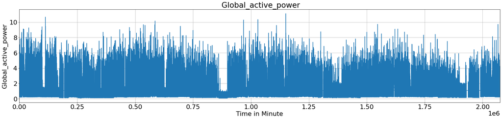

```python
figPath = 'figs/'
fig = plt.figure(figsize = (30,6))
plt.title(' Global_active_power')
plt.ylabel('Global_active_power')
plt.xlabel('Time in Minute')
plt.grid(True)
plt.autoscale(axis='x',tight=True)
plt.plot(householdPower.Global_active_power)
plt.show()
fig.savefig(figPath + 'global_active_power_actual_minute.png', dpi = 300)
```

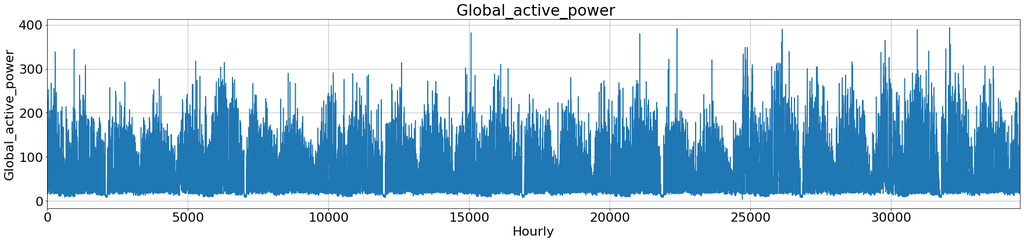

```python
fig = plt.figure(figsize = (30,6))
plt.title(' Global_active_power')
plt.ylabel('Global_active_power')
plt.xlabel('Hourly')
plt.grid(True)
plt.autoscale(axis='x',tight=True)
plt.plot(householdPowerhourly.Global_active_power)
plt.show()
fig.savefig(figPath + 'global_active_power_actual_hourly.png', dpi = 300)

# Note: periodicity = 1200 hours
```

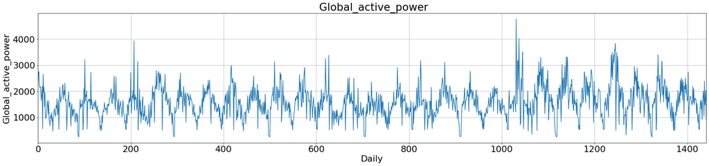

```python
fig = plt.figure(figsize = (30,6))
plt.title(' Global_active_power')
plt.ylabel('Global_active_power')
plt.xlabel('Daily')
plt.grid(True)
plt.autoscale(axis='x',tight=True)
plt.plot(householdPowerdaily.Global_active_power) # 27 days cycle
plt.show()
fig.savefig(figPath + 'global_active_power_actual_daily.png', dpi = 300)

# Note: periodicity = 30 days
```

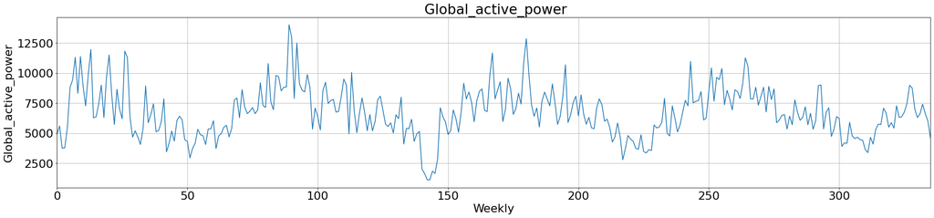

```python
fig = plt.figure(figsize = (30,6))
plt.title(' Global_active_power')
plt.ylabel('Global_active_power')
plt.xlabel('Weekly')
plt.grid(True)
plt.autoscale(axis='x',tight=True)
plt.plot(householdPowerweekly.Global_active_power)
plt.show()
fig.savefig(figPath + 'global_active_power_actual_weekly.png', dpi = 300)
# Note: periodicity = 50 weeks
```

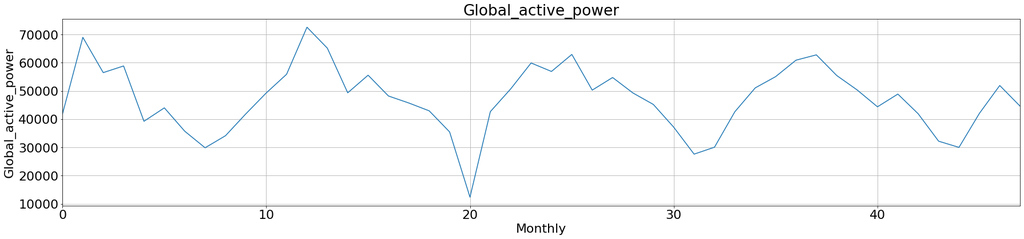

```python
fig = plt.figure(figsize = (30,6))
plt.title('Global_active_power')
plt.ylabel('Global_active_power')
plt.xlabel('Monthly')
plt.grid(True)
plt.autoscale(axis='x',tight=True)
plt.plot(householdPowermonthly.Global_active_power)
plt.show()
fig.savefig(figPath + 'global_active_power_actual_monthly.png', dpi = 300)
# Note: periodicity = 5-7 months
```

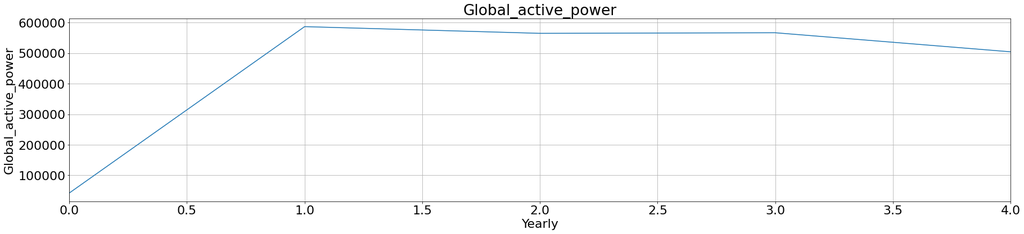

```python
fig = plt.figure(figsize = (30,6))
plt.title('Global_active_power')
plt.ylabel('Global_active_power')
plt.xlabel('Yearly')
plt.grid(True)
plt.autoscale(axis='x',tight=True)
plt.plot(householdPoweryearly.Global_active_power)
plt.show()
fig.savefig(figPath + 'global_active_power_actual_yearly.png', dpi = 300)
# Note: No periodicity
```

# Results

```python
# helper functions
torch.manual_seed(1)
def data_preparation(training_set, sequence_window_size = 27):
    '''This function takes training dataset (in dataframe form) and returns PyTorch tensors.'''
    def data_slicer(data, seq_length):
        x = []
        y = []

        for i in range(len(data)-seq_length-1):
            _x = data[i:(i+seq_length)]
            _y = data[i+seq_length]
            x.append(_x)
            y.append(_y)

        return np.array(x),np.array(y)

    sc = MinMaxScaler()
    training_data = sc.fit_transform(training_set)

    seq_length = sequence_window_size
    x, y = data_slicer(training_data, seq_length)

    train_size = int(len(y) * 0.7)
    test_size = len(y) - train_size

    dataX = Variable(torch.Tensor(np.array(x)))
    dataY = Variable(torch.Tensor(np.array(y)))

    trainX = Variable(torch.Tensor(np.array(x[0:train_size])))
    trainY = Variable(torch.Tensor(np.array(y[0:train_size])))

    testX = Variable(torch.Tensor(np.array(x[train_size:len(x)])))
    testY = Variable(torch.Tensor(np.array(y[train_size:len(y)])))

    return dataX, dataY, trainX, trainY, testX, testY, train_size, sc


def plot_data(data_predict, dataY_plot, train_size, w_type = 'D', toPath = figPath):
    '''This function plots global active power at different time frames.
    w_type valid parameters {"D", "M","W"}.
    "D" stands for daily, "M" stands for monthly and "W" stands for weekly forecast. '''
    fileSuffix = ''
    title = 'Global Active Power Forecast'
    if w_type == 'D':
        xlabel = 'Daily'
        fileSuffix = 'daily'
    elif w_type == 'M':
        xlabel = 'Monthly'
        fileSuffix = 'monthly'
    elif  w_type == 'W':
        xlabel = 'Weekly'
        fileSuffix = 'weekly'

    fig = plt.figure(figsize = (30,6))
    plt.axvline(x=train_size, c='r', linestyle='--')
    yhat = dataY_plot[:train_size+1].tolist() + data_predict[train_size-1:].tolist()
    plt.plot(yhat, label = 'Forecast', color = 'orange')
    plt.plot(dataY_plot, label = 'Actual')
    plt.suptitle(title)
    plt.xlabel(xlabel)
    plt.ylabel('Global_active_power')
    plt.legend()
    plt.show()
    fig.savefig(figPath + 'global_active_power_forecasted_'+fileSuffix+'.png', dpi = 300)

def mape(y, yhat):
    return sum(abs((y - yhat)/y))/len(y) * 100

def evaluate(model, dataX, dataY, sc, train_size):
    model.eval()
    train_predict = model(dataX)

    data_predict = train_predict.data.numpy()
    dataY_plot = dataY.data.numpy()

    data_predict = sc.inverse_transform(data_predict)
    dataY_plot = sc.inverse_transform(dataY_plot)

    mdf = pd.DataFrame({'y':data_predict.ravel()[train_size-1:], 'yhat':dataY_plot.ravel()[train_size-1:]})
    print('MAPE: {}%'.format(round(mape(mdf.y, mdf.yhat)), 4))

    return data_predict, dataY_plot
```

```python
# LSTM model
class GAPforecast(nn.Module):
    def __init__(self, num_classes, input_size, hidden_size, num_layers):
        super(GAPforecast, self).__init__()

        self.num_classes = num_classes
        self.num_layers = num_layers
        self.input_size = input_size
        self.hidden_size = hidden_size

        self.lstm = nn.LSTM(input_size=input_size, hidden_size=hidden_size,
                            num_layers=num_layers, batch_first=True)

        self.fc = nn.Linear(hidden_size, num_classes)

    def forward(self, x):
        h_0 = Variable(torch.zeros(
            self.num_layers, x.size(0), self.hidden_size))
        c_0 = Variable(torch.zeros(
            self.num_layers, x.size(0), self.hidden_size))
        # Propagate input through LSTM
        ula, (h_out, _) = self.lstm(x, (h_0, c_0))
        h_out = h_out.view(-1, self.hidden_size)
        out = self.fc(h_out)
        return out

# train lstm model
def trainNet(trainX, trainY, testX, testY, n_epochs, seq_length, learning_rate = 0.01, optimizer_type = 'A'):
    n_epochs = n_epochs
    learning_rate = learning_rate

    # Model Architecture Components
    input_size = 1
    hidden_size = 4
    num_layers = 1

    num_classes = 1

    # Instantiate class GAPforecast object
    model = GAPforecast(num_classes, input_size, hidden_size, num_layers)

    criterion = torch.nn.MSELoss()    # mean-squared error
    if optimizer_type == 'A':
        optimizer = torch.optim.Adam(model.parameters(), lr=learning_rate)
    else:
        optimizer = torch.optim.SGD(model.parameters(), lr=learning_rate)

    # Train the model
    for epoch in range(n_epochs):
        trainloss = 0.0

        outputs = model(trainX)
        optimizer.zero_grad()

        # obtain the loss function
        loss = criterion(outputs, trainY)

        loss.backward()

        optimizer.step()
        trainloss = loss.item()
        if epoch % 100 == 0:
            print("Epoch: %d, \tTraining Loss: %1.5f" % (epoch, loss.item()))

    return model
```

###### Model training and performance Validation

```
Epoch: 0, 	Training Loss: 0.01410
Epoch: 100, 	Training Loss: 0.00988
Epoch: 200, 	Training Loss: 0.00981
Epoch: 300, 	Training Loss: 0.00976
Epoch: 400, 	Training Loss: 0.00974
Epoch: 500, 	Training Loss: 0.00974
Epoch: 600, 	Training Loss: 0.00974
Epoch: 700, 	Training Loss: 0.00973
Epoch: 800, 	Training Loss: 0.00973
Epoch: 900, 	Training Loss: 0.00972
Epoch: 1000, 	Training Loss: 0.00971
Epoch: 1100, 	Training Loss: 0.00970
Epoch: 1200, 	Training Loss: 0.00968
Epoch: 1300, 	Training Loss: 0.00966
Epoch: 1400, 	Training Loss: 0.00964
Epoch: 1500, 	Training Loss: 0.00963
Epoch: 1600, 	Training Loss: 0.00963
Epoch: 1700, 	Training Loss: 0.00962
Epoch: 1800, 	Training Loss: 0.00962
Epoch: 1900, 	Training Loss: 0.00961
MAPE: 32%
```

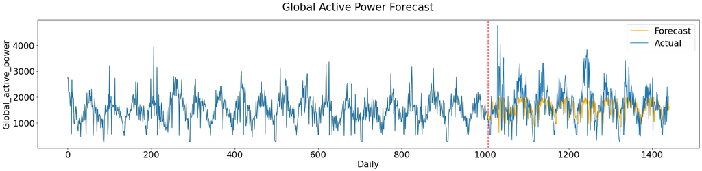

```python
## model performance at daily level
sequence_size = 1
training_set = householdPowerdaily.iloc[:,4:].values
freq = 'D'

# prepare data for training
dataX, dataY, trainX, trainY, testX, testY, train_size, sc = data_preparation(training_set, sequence_window_size = sequence_size)
# training model
model = trainNet(trainX, trainY, testX, testY, n_epochs = 2000, seq_length = sequence_size )
# model evaluation
data_predict, dataY_plot = evaluate(model, dataX, dataY, sc, train_size)
# plot forecasted results
plot_data(data_predict, dataY_plot, w_type=freq, train_size = train_size, toPath = figPath)
```

```
Epoch: 0, 	Training Loss: 0.15731
Epoch: 100, 	Training Loss: 0.02011
Epoch: 200, 	Training Loss: 0.01702
Epoch: 300, 	Training Loss: 0.01675
Epoch: 400, 	Training Loss: 0.01653
Epoch: 500, 	Training Loss: 0.01637
Epoch: 600, 	Training Loss: 0.01630
Epoch: 700, 	Training Loss: 0.01628
Epoch: 800, 	Training Loss: 0.01627
Epoch: 900, 	Training Loss: 0.01627
Epoch: 1000, 	Training Loss: 0.01627
Epoch: 1100, 	Training Loss: 0.01627
Epoch: 1200, 	Training Loss: 0.01627
Epoch: 1300, 	Training Loss: 0.01627
Epoch: 1400, 	Training Loss: 0.01627
Epoch: 1500, 	Training Loss: 0.01627
Epoch: 1600, 	Training Loss: 0.01627
Epoch: 1700, 	Training Loss: 0.01627
Epoch: 1800, 	Training Loss: 0.01627
Epoch: 1900, 	Training Loss: 0.01627
MAPE: 15%
```

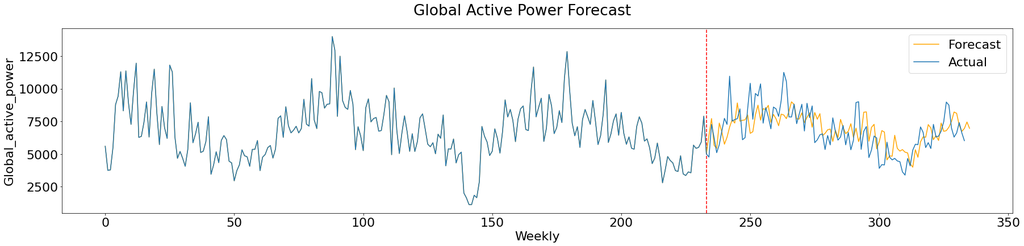

```python
## model performance at weekly level
sequence_size = 1
n_epochs = 2000
freq = 'W'

training_set = householdPowerweekly.iloc[:,3:].values

# prepare data for training
dataX, dataY, trainX, trainY, testX, testY, train_size, sc = data_preparation(training_set, sequence_window_size = sequence_size)
# training model
model = trainNet(trainX, trainY, testX, testY, n_epochs = n_epochs, seq_length = sequence_size )
# model evaluation
data_predict, dataY_plot = evaluate(model, dataX, dataY, sc, train_size)
# plot forecasted results
plot_data(data_predict, dataY_plot, train_size, w_type=freq, toPath = figPath)
```

```
Epoch: 0, 	Training Loss: 0.09087
Epoch: 100, 	Training Loss: 0.03049
Epoch: 200, 	Training Loss: 0.02978
Epoch: 300, 	Training Loss: 0.02963
Epoch: 400, 	Training Loss: 0.02939
Epoch: 500, 	Training Loss: 0.02895
Epoch: 600, 	Training Loss: 0.02828
Epoch: 700, 	Training Loss: 0.02743
Epoch: 800, 	Training Loss: 0.02511
Epoch: 900, 	Training Loss: 0.02430
Epoch: 1000, 	Training Loss: 0.02424
Epoch: 1100, 	Training Loss: 0.02418
Epoch: 1200, 	Training Loss: 0.02408
Epoch: 1300, 	Training Loss: 0.02395
Epoch: 1400, 	Training Loss: 0.02380
Epoch: 1500, 	Training Loss: 0.02366
Epoch: 1600, 	Training Loss: 0.02366
Epoch: 1700, 	Training Loss: 0.02351
Epoch: 1800, 	Training Loss: 0.02347
Epoch: 1900, 	Training Loss: 0.02357
MAPE: 15%
```

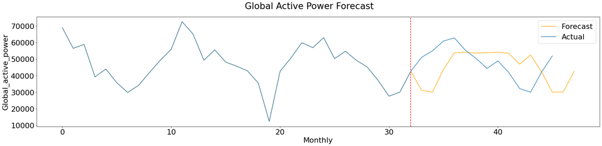

```python
## model performance at monthly level
sequence_size = 1
n_epochs = 2000
freq = 'M'

training_set = householdPowermonthly.iloc[:,2:].values

# prepare data for training
dataX, dataY, trainX, trainY, testX, testY, train_size, sc = data_preparation(training_set, sequence_window_size = sequence_size)
# training model
model = trainNet(trainX, trainY, testX, testY, n_epochs = n_epochs, seq_length = sequence_size )
# model evaluation
data_predict, dataY_plot = evaluate(model, dataX, dataY, sc, train_size)
# plot forecasted results
plot_data(data_predict, dataY_plot, train_size, w_type=freq, toPath = figPath)
```

# Conclusion

- It is observed that global active power has decreased year 2010 onwards [shown in fig. global_active_power_actual_yearly.png]
- The lstm model peformance is best on weekly and monthly aggregated data. The MAPE of the forecast on each of the level on test dataset is as shown in the table.

| Time Frame |  | MAPE (%) |
| --- | --- | --- |
| Daily |  | 32 |
| Weekly |  | 15 |
| Monthly |  | 15 |

- Forecasting global active power at minute level is relatively slow and needs high speed infrastructure to train LSTM.
- With missing values, the current model performance good enough using LSTM

# Scope of Improvement/Future work

The current work can be further improved by considering to handle identified challeneges in different ways. The best approach can be identified by designing and conducting experiments. The open items that can further improved are -

- Fetching actual values of the missing values rather than imputation would ehance model performance.
- Using pre-trained model on relevant dataset would help to reduce model training time and also, avoid over-fitting of the model.
- Global active power forcasting at minute and hour level can be done using high speed machine. The infrastructure used in this project were taking longer time training time and thus, can not be explored extensively.
- Using similar, approach electrical meters readings can be forecasted.